# Session 1 Exercises (with answers)

Ben Raymond, Adrien Ickowicz

# Preparation

Load some packages:

```r
library(tidyverse)
library(lubridate)
```

And read in our data (set scores from the 2019 D1 Women’s NCAA competition, scraped from the NCAA web site).

```r
x <- read_csv("example_data/NCAA_D1W_2019.csv")

glimpse(x)
```

```
## Rows: 18,361
## Columns: 14
## $ competition             <chr> "NCAA D1 Women 2019", "NCAA D1 Women 2019", "N…
## $ mf                      <chr> "female", "female", "female", "female", "femal…
## $ level                   <chr> "College", "College", "College", "College", "C…
## $ match_id                <chr> "NCAA_D1W19-1775048", "NCAA_D1W19-1775048", "N…
## $ date                    <date> 2019-08-30, 2019-08-30, 2019-08-30, 2019-08-3…
## $ home_team               <chr> "Weber State", "Weber State", "Weber State", "…
## $ visiting_team           <chr> "UNLV", "UNLV", "UNLV", "UNLV", "Northeastern"…
## $ match_n_sets            <dbl> 4, 4, 4, 4, 4, 4, 4, 4, 3, 3, 3, 3, 3, 3, 3, 3…
## $ home_team_set_score     <dbl> 3, 3, 3, 3, 3, 3, 3, 3, 3, 3, 3, 3, 3, 3, 3, 3…
## $ visiting_team_set_score <dbl> 1, 1, 1, 1, 1, 1, 1, 1, 0, 0, 0, 0, 0, 0, 0, 0…
## $ set_number              <dbl> 1, 2, 3, 4, 1, 2, 3, 4, 1, 2, 3, 1, 2, 3, 1, 2…
## $ home_team_score         <dbl> 25, 24, 25, 25, 25, 26, 27, 25, 25, 25, 25, 25…
## $ visiting_team_score     <dbl> 22, 26, 17, 23, 16, 28, 25, 23, 17, 20, 18, 20…
## $ margin                  <dbl> 3, 2, 8, 2, 9, 2, 2, 2, 8, 5, 7, 5, 6, 8, 6, 5…
```

# Exercises

### 1. What is the date range of the matches?

**Click for solution**

```r
range(x$date)
```

```
## [1] "2019-08-30" "2019-12-21"
```

### 2. How many matches were played?

**Click for solution**

```r
length(unique(x$match_id))
```

```
## [1] 4924
```

### 3. How many teams?

**Click for solution**

```r
length(unique(c(x$home_team, x$visiting_team)))
```

```
## [1] 335
```

### 4. Count the number of matches that went to 3, 4, and 5 sets

**Click for solution**

```r
x %>% group_by(match_id) %>% slice(1) %>% ungroup %>% ## one row per match
    count(match_n_sets) ## count the number of times each value of match_n_sets appears
```

```
## # A tibble: 3 × 2
##   match_n_sets     n
##          <dbl> <int>
## 1            3  2360
## 2            4  1539
## 3            5  1025
```

```r
## or
x %>% distinct(match_id, match_n_sets) %>%
    count(match_n_sets)
```

```
## # A tibble: 3 × 2
##   match_n_sets     n
##          <dbl> <int>
## 1            3  2360
## 2            4  1539
## 3            5  1025
```

### 5. On average, how many sets were played per match?

**Click for solution**

```r
x %>% group_by(match_id) %>% slice(1) %>% ungroup %>%
    dplyr::summarize(mean_n_sets = mean(match_n_sets))
```

```
## # A tibble: 1 × 1
##   mean_n_sets
##         <dbl>
## 1        3.73
```

```r
## or
nrow(x) / length(unique(x$match_id))
```

```
## [1] 3.728879
```

### 6. How many matches did Weber State play?

**Click for solution**

```r
x %>% filter(home_team == "Weber State" | visiting_team == "Weber State") %>%
    summarize(n_matches = length(unique(match_id)))
```

```
## # A tibble: 1 × 1
##   n_matches
##       <int>
## 1        35
```

or perhaps

```r
x %>% filter(home_team == "Weber State" | visiting_team == "Weber State") %>%
    distinct(match_id) %>% nrow
```

```
## [1] 35
```

or even

```r
length(unique(x$match_id[x$home_team == "Weber State" | x$visiting_team == "Weber State"]))
```

```
## [1] 35
```

### 7. List the top 10 teams in terms of the most matches played

**Click for solution**

```r
bind_rows(x %>% distinct(match_id, team = home_team),
          x %>% distinct(match_id, team = visiting_team)) %>%
    count(team) %>% ## count the number of times each team name appears
    dplyr::arrange(desc(n)) %>% ## arrange in decreasing count order
    head(10) ## first 10 rows
```

```
## # A tibble: 10 × 2
##    team               n
##    <chr>          <int>
##  1 Alabama State     36
##  2 Jackson State     35
##  3 Prairie View      35
##  4 Weber State       35
##  5 Cincinnati        34
##  6 Illinois State    34
##  7 Marquette         34
##  8 Northern Colo.    34
##  9 Stanford          34
## 10 Tulsa             34
```

### 8. Can you re-create the `margin` column, using the other columns in the data set?

**Click for solution**

```r
## add some extra columns
x <- x %>% mutate(margin = abs(home_team_score - visiting_team_score))
```

### 9. What was the average winning margin of a set?

**Click for solution**

```r
mean(x$margin)
```

```
## [1] 5.958227
```

### 10. Does that vary by set number 1–5?

**Click for solution**

```r
x %>% group_by(set_number) %>% dplyr::summarize(mean_winning_margin = mean(margin))
```

```
## # A tibble: 5 × 2
##   set_number mean_winning_margin
##        <dbl>               <dbl>
## 1          1                6.12
## 2          2                6.14
## 3          3                6.02
## 4          4                5.89
## 5          5                4.14
```

### 11. Plot a histogram of the score margin (all sets combined)

**Click for solution**

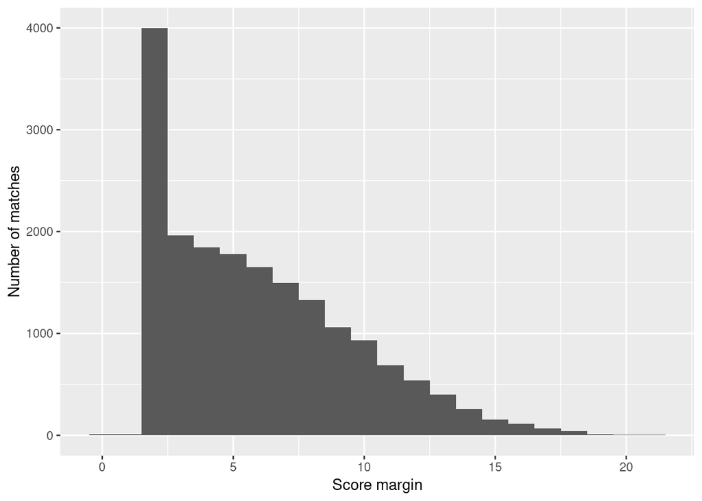

```r
ggplot(x, aes(x = margin)) + geom_histogram(binwidth = 1) +
    labs(x = "Score margin", y = "Number of matches")
```

### 12. Same thing with each set shown separately

**Click for solution**

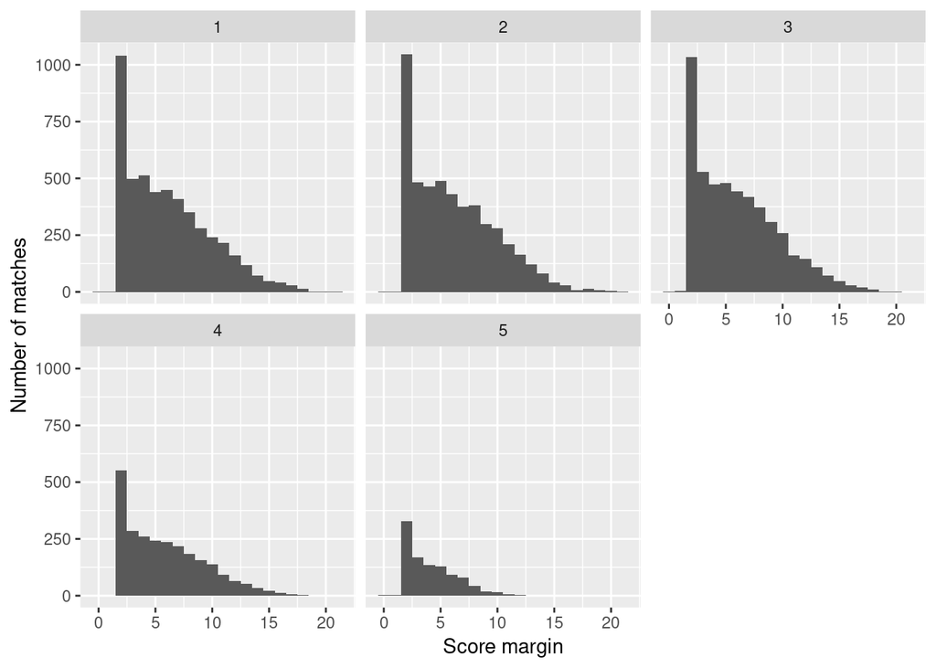

```r
ggplot(x, aes(x = margin)) + geom_histogram(binwidth = 1) +
    facet_wrap(~set_number) +
    labs(x = "Score margin", y = "Number of matches")
```

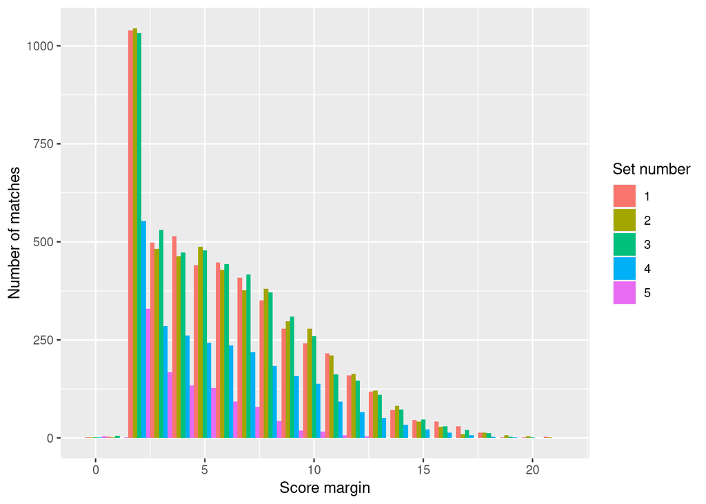

```r
## or
ggplot(x, aes(x = margin, group = set_number, fill = as.factor(set_number))) +
    geom_histogram(binwidth = 1, position = "dodge") + scale_fill_discrete(name = "Set number") +
    labs(x = "Score margin", y = "Number of matches")
```

### 13. Find the most one-sided set result

**Click for solution**

```r
x %>% slice_max(margin)
```

```
## # A tibble: 5 × 14
##   competition        mf     level   match_id  date       home_team visiting_team
##   <chr>              <chr>  <chr>   <chr>     <date>     <chr>     <chr>
## 1 NCAA D1 Women 2019 female College NCAA_D1W… 2019-09-07 Louisiana Florida A&M
## 2 NCAA D1 Women 2019 female College NCAA_D1W… 2019-09-07 Tulane    Houston Bapt…
## 3 NCAA D1 Women 2019 female College NCAA_D1W… 2019-09-13 SFA       Ark.-Pine Bl…
## 4 NCAA D1 Women 2019 female College NCAA_D1W… 2019-10-22 Sacred H… Merrimack
## 5 NCAA D1 Women 2019 female College NCAA_D1W… 2019-11-20 Purdue    Rutgers
## # … with 7 more variables: match_n_sets <dbl>, home_team_set_score <dbl>,
## #   visiting_team_set_score <dbl>, set_number <dbl>, home_team_score <dbl>,
## #   visiting_team_score <dbl>, margin <dbl>
```

```r
## or
x[which(x$margin == max(x$margin)), ]
```

```
## # A tibble: 5 × 14
##   competition        mf     level   match_id  date       home_team visiting_team
##   <chr>              <chr>  <chr>   <chr>     <date>     <chr>     <chr>
## 1 NCAA D1 Women 2019 female College NCAA_D1W… 2019-09-07 Louisiana Florida A&M
## 2 NCAA D1 Women 2019 female College NCAA_D1W… 2019-09-07 Tulane    Houston Bapt…
## 3 NCAA D1 Women 2019 female College NCAA_D1W… 2019-09-13 SFA       Ark.-Pine Bl…
## 4 NCAA D1 Women 2019 female College NCAA_D1W… 2019-10-22 Sacred H… Merrimack
## 5 NCAA D1 Women 2019 female College NCAA_D1W… 2019-11-20 Purdue    Rutgers
## # … with 7 more variables: match_n_sets <dbl>, home_team_set_score <dbl>,
## #   visiting_team_set_score <dbl>, set_number <dbl>, home_team_score <dbl>,
## #   visiting_team_score <dbl>, margin <dbl>
```

### 14. Is there a home team advantage? Find the match win rate for the home team (ignore the fact that some of these matches were played at neutral venues — just take the `home_team` and `visiting_team` column names on face value)

**Click for solution**

```r
x <- x %>% group_by(match_id) %>% mutate(match_won_by = case_when(home_team_set_score > visiting_team_set_score ~ home_team,
                                                                  TRUE ~ visiting_team)) %>%
    ungroup

## but
x %>% dplyr::filter(match_won_by == visiting_team & visiting_team_set_score <= home_team_set_score)
```

```
## # A tibble: 5 × 15
##   competition        mf     level   match_id  date       home_team visiting_team
##   <chr>              <chr>  <chr>   <chr>     <date>     <chr>     <chr>
## 1 NCAA D1 Women 2019 female College NCAA_D1W… 2019-09-06 American  Ohio
## 2 NCAA D1 Women 2019 female College NCAA_D1W… 2019-09-06 American  Ohio
## 3 NCAA D1 Women 2019 female College NCAA_D1W… 2019-09-06 American  Ohio
## 4 NCAA D1 Women 2019 female College NCAA_D1W… 2019-09-06 American  Ohio
## 5 NCAA D1 Women 2019 female College NCAA_D1W… 2019-09-06 American  Ohio
## # … with 8 more variables: match_n_sets <dbl>, home_team_set_score <dbl>,
## #   visiting_team_set_score <dbl>, set_number <dbl>, home_team_score <dbl>,
## #   visiting_team_score <dbl>, margin <dbl>, match_won_by <chr>
```

```r
## so
x <- x %>% group_by(match_id) %>% mutate(match_won_by = case_when(home_team_set_score > visiting_team_set_score ~ home_team,
                                                                  visiting_team_set_score > home_team_set_score ~ visiting_team)) %>%
    ungroup

x <- x %>% mutate(home_team_won_match = case_when(match_won_by == home_team ~ TRUE,
                                                  match_won_by == visiting_team ~ FALSE))

## and finally
x %>% group_by(match_id) %>% slice(1) %>% ungroup %>%
    dplyr::summarize(p_home_win = mean(home_team_won_match, na.rm = TRUE))
```

```
## # A tibble: 1 × 1
##   p_home_win
##        <dbl>
## 1      0.580
```

```r
## or
x %>% distinct(match_id, home_team_won_match) %>%
    dplyr::summarize(p_home_win = mean(home_team_won_match, na.rm = TRUE))
```

```
## # A tibble: 1 × 1
##   p_home_win
##        <dbl>
## 1      0.580
```